# Machine Learning Engineer Nanodegree

### Implementation: Outlier Detection

Detecting outliers in the data is extremely important in the data preprocessing step of any analysis. The presence of outliers can often skew results which take into consideration these data points. There are many "rules of thumb" for what constitutes an outlier in a dataset. Here, we will use [Tukey's Method for identfying outliers](http://datapigtechnologies.com/blog/index.php/highlighting-outliers-in-your-data-with-the-tukey-method/): An *outlier step* is calculated as 1.5 times the interquartile range (IQR). A data point with a feature that is beyond an outlier step outside of the IQR for that feature is considered abnormal.

In the code block below, you will need to implement the following:

- Assign the value of the 25th percentile for the given feature to `Q1`. Use `np.percentile` for this.
- Assign the value of the 75th percentile for the given feature to `Q3`. Again, use `np.percentile`.
- Assign the calculation of an outlier step for the given feature to `step`.
- Optionally remove data points from the dataset by adding indices to the `outliers` list.

**NOTE:** If you choose to remove any outliers, ensure that the sample data does not contain any of these points!  
Once you have performed this implementation, the dataset will be stored in the variable `good_data`.

```python
# For each feature find the data points with extreme high or low values

outliers_all = []
for feature in log_data.keys():

    # TODO: Calculate Q1 (25th percentile of the data) for the given feature
    Q1 = np.percentile(log_data.loc[:, feature], 25)

    # TODO: Calculate Q3 (75th percentile of the data) for the given feature
    Q3 = np.percentile(log_data.loc[:, feature], 75)

    # TODO: Use the interquartile range to calculate an outlier step (1.5 times the interquartile range)
    step = 1.5*(Q3-Q1)

    # Display the outliers
    print "Data points considered outliers for the feature '{}':".format(feature)
    feature_outliers = (log_data[~((log_data[feature] >= Q1 - step) & (log_data[feature] <= Q3 + step))])
    display(feature_outliers)
    outliers_all.extend(list(feature_outliers.index.values))

    # code given where ~ <=> not

# OPTIONAL: Select the indices for data points you wish to remove
outliers  = []

# Remove the outliers, if any were specified
good_data = log_data.drop(log_data.index[outliers]).reset_index(drop = True)

display(log_data.describe())

outliers_mult = [item for item, count in Counter(outliers_all).iteritems() if count > 1]
print('Outliers in multiple Features', outliers_mult)

outliers_mult2 = [item for item, count in Counter(outliers_all).iteritems() if count > 2]

print('Outliers in more than 2 multiple Features', outliers_mult2)

pd.scatter_matrix(log_data, alpha = 0.3, figsize = (14,8), diagonal = 'kde');
```

```
Data points considered outliers for the feature 'Fresh':
```

|  | Fresh | Milk | Grocery | Frozen | Detergents_Paper | Delicatessen |
| --- | --- | --- | --- | --- | --- | --- |
| 65 | 4.442651 | 9.950323 | 10.732651 | 3.583519 | 10.095388 | 7.260523 |
| 66 | 2.197225 | 7.335634 | 8.911530 | 5.164786 | 8.151333 | 3.295837 |
| 81 | 5.389072 | 9.163249 | 9.575192 | 5.645447 | 8.964184 | 5.049856 |
| 95 | 1.098612 | 7.979339 | 8.740657 | 6.086775 | 5.407172 | 6.563856 |
| 96 | 3.135494 | 7.869402 | 9.001839 | 4.976734 | 8.262043 | 5.379897 |
| 128 | 4.941642 | 9.087834 | 8.248791 | 4.955827 | 6.967909 | 1.098612 |
| 171 | 5.298317 | 10.160530 | 9.894245 | 6.478510 | 9.079434 | 8.740337 |
| 193 | 5.192957 | 8.156223 | 9.917982 | 6.865891 | 8.633731 | 6.501290 |
| 218 | 2.890372 | 8.923191 | 9.629380 | 7.158514 | 8.475746 | 8.759669 |
| 304 | 5.081404 | 8.917311 | 10.117510 | 6.424869 | 9.374413 | 7.787382 |
| 305 | 5.493061 | 9.468001 | 9.088399 | 6.683361 | 8.271037 | 5.351858 |
| 338 | 1.098612 | 5.808142 | 8.856661 | 9.655090 | 2.708050 | 6.309918 |
| 353 | 4.762174 | 8.742574 | 9.961898 | 5.429346 | 9.069007 | 7.013016 |
| 355 | 5.247024 | 6.588926 | 7.606885 | 5.501258 | 5.214936 | 4.844187 |
| 357 | 3.610918 | 7.150701 | 10.011086 | 4.919981 | 8.816853 | 4.700480 |
| 412 | 4.574711 | 8.190077 | 9.425452 | 4.584967 | 7.996317 | 4.127134 |

```
Data points considered outliers for the feature 'Milk':
```

|  | Fresh | Milk | Grocery | Frozen | Detergents_Paper | Delicatessen |
| --- | --- | --- | --- | --- | --- | --- |
| 86 | 10.039983 | 11.205013 | 10.377047 | 6.894670 | 9.906981 | 6.805723 |
| 98 | 6.220590 | 4.718499 | 6.656727 | 6.796824 | 4.025352 | 4.882802 |
| 154 | 6.432940 | 4.007333 | 4.919981 | 4.317488 | 1.945910 | 2.079442 |
| 356 | 10.029503 | 4.897840 | 5.384495 | 8.057377 | 2.197225 | 6.306275 |

```
Data points considered outliers for the feature 'Grocery':
```

|  | Fresh | Milk | Grocery | Frozen | Detergents_Paper | Delicatessen |
| --- | --- | --- | --- | --- | --- | --- |
| 75 | 9.923192 | 7.036148 | 1.098612 | 8.390949 | 1.098612 | 6.882437 |
| 154 | 6.432940 | 4.007333 | 4.919981 | 4.317488 | 1.945910 | 2.079442 |

```
Data points considered outliers for the feature 'Frozen':
```

|  | Fresh | Milk | Grocery | Frozen | Detergents_Paper | Delicatessen |
| --- | --- | --- | --- | --- | --- | --- |
| 38 | 8.431853 | 9.663261 | 9.723703 | 3.496508 | 8.847360 | 6.070738 |
| 57 | 8.597297 | 9.203618 | 9.257892 | 3.637586 | 8.932213 | 7.156177 |
| 65 | 4.442651 | 9.950323 | 10.732651 | 3.583519 | 10.095388 | 7.260523 |
| 145 | 10.000569 | 9.034080 | 10.457143 | 3.737670 | 9.440738 | 8.396155 |
| 175 | 7.759187 | 8.967632 | 9.382106 | 3.951244 | 8.341887 | 7.436617 |
| 264 | 6.978214 | 9.177714 | 9.645041 | 4.110874 | 8.696176 | 7.142827 |
| 325 | 10.395650 | 9.728181 | 9.519735 | 11.016479 | 7.148346 | 8.632128 |
| 420 | 8.402007 | 8.569026 | 9.490015 | 3.218876 | 8.827321 | 7.239215 |
| 429 | 9.060331 | 7.467371 | 8.183118 | 3.850148 | 4.430817 | 7.824446 |
| 439 | 7.932721 | 7.437206 | 7.828038 | 4.174387 | 6.167516 | 3.951244 |

```
Data points considered outliers for the feature 'Detergents_Paper':
```

|  | Fresh | Milk | Grocery | Frozen | Detergents_Paper | Delicatessen |
| --- | --- | --- | --- | --- | --- | --- |
| 75 | 9.923192 | 7.036148 | 1.098612 | 8.390949 | 1.098612 | 6.882437 |
| 161 | 9.428190 | 6.291569 | 5.645447 | 6.995766 | 1.098612 | 7.711101 |

```
Data points considered outliers for the feature 'Delicatessen':
```

|  | Fresh | Milk | Grocery | Frozen | Detergents_Paper | Delicatessen |
| --- | --- | --- | --- | --- | --- | --- |
| 66 | 2.197225 | 7.335634 | 8.911530 | 5.164786 | 8.151333 | 3.295837 |
| 109 | 7.248504 | 9.724899 | 10.274568 | 6.511745 | 6.728629 | 1.098612 |
| 128 | 4.941642 | 9.087834 | 8.248791 | 4.955827 | 6.967909 | 1.098612 |
| 137 | 8.034955 | 8.997147 | 9.021840 | 6.493754 | 6.580639 | 3.583519 |
| 142 | 10.519646 | 8.875147 | 9.018332 | 8.004700 | 2.995732 | 1.098612 |
| 154 | 6.432940 | 4.007333 | 4.919981 | 4.317488 | 1.945910 | 2.079442 |
| 183 | 10.514529 | 10.690808 | 9.911952 | 10.505999 | 5.476464 | 10.777768 |
| 184 | 5.789960 | 6.822197 | 8.457443 | 4.304065 | 5.811141 | 2.397895 |
| 187 | 7.798933 | 8.987447 | 9.192075 | 8.743372 | 8.148735 | 1.098612 |
| 203 | 6.368187 | 6.529419 | 7.703459 | 6.150603 | 6.860664 | 2.890372 |
| 233 | 6.871091 | 8.513988 | 8.106515 | 6.842683 | 6.013715 | 1.945910 |
| 285 | 10.602965 | 6.461468 | 8.188689 | 6.948897 | 6.077642 | 2.890372 |
| 289 | 10.663966 | 5.655992 | 6.154858 | 7.235619 | 3.465736 | 3.091042 |
| 343 | 7.431892 | 8.848509 | 10.177932 | 7.283448 | 9.646593 | 3.610918 |

|  | Fresh | Milk | Grocery | Frozen | Detergents_Paper | Delicatessen |
| --- | --- | --- | --- | --- | --- | --- |
| count | 440.000000 | 440.000000 | 440.000000 | 440.000000 | 440.000000 | 440.000000 |
| mean | 8.730544 | 8.121047 | 8.441169 | 7.301396 | 6.785972 | 6.665133 |
| std | 1.480071 | 1.081365 | 1.116172 | 1.284540 | 1.721020 | 1.310832 |
| min | 1.098612 | 4.007333 | 1.098612 | 3.218876 | 1.098612 | 1.098612 |
| 25% | 8.048059 | 7.334981 | 7.674616 | 6.609678 | 5.548101 | 6.011875 |
| 50% | 9.048286 | 8.196159 | 8.467057 | 7.330388 | 6.705018 | 6.872645 |
| 75% | 9.737064 | 8.880480 | 9.273854 | 8.175896 | 8.274341 | 7.506728 |
| max | 11.627601 | 11.205013 | 11.437986 | 11.016479 | 10.617099 | 10.777768 |

[output not shown]

### Question 4

- Are there any data points considered outliers for more than one feature based on the definition above?
- Should these data points be removed from the dataset?
- If any data points were added to the `outliers` list to be removed, explain why.

**Hint:** If you have datapoints that are outliers in multiple categories think about why that may be and if they warrant removal. Also note how k-means is affected by outliers and whether or not this plays a factor in your analysis of whether or not to remove them.

A: I am very reluctant to declared 'any' data an outlier, but in the context of segmenting a market, the extreme poimts can skew the results greatly. So using the John Tukey's 1.5*IQR outlier rule of thumb, I have the following statistical boundaries:

```
     Fresh      Milk        Grocery     Frozen  D  etergents_Paper  Delicatessen
```

IQR 1.689005 1.545499 1.599238 1.566218 2.72624 1.494853 IQR*1.5 2.5335075 2.3182485 2.398857 2.349327 4.08936 2.2422795

Lower 5.5145515 5.0167325 5.275759 4.260351 1.458741 3.7695955 Upper 12.2705715 11.1987285 11.672711 10.525223 12.363701 9.7490075

C: There are 4 data who are on 2 feature outlier lists (#65, #66, #75, #128) with 1 datum on 3 feature outlier lists (#154), all 5 of these data are too "low" according to the Tukey Rule of thumb.

"There is no statistical theory that seperates non-outliers", Bruce, P. , A. Bruce, Practical Statistics for Data Scientist, O'Reilly, 2017, p 156.

## Feature Transformation

In this section you will use principal component analysis (PCA) to draw conclusions about the underlying structure of the wholesale customer data. Since using PCA on a dataset calculates the dimensions which best maximize variance, we will find which compound combinations of features best describe customers.

### Implementation: PCA

Now that the data has been scaled to a more normal distribution and has had any necessary outliers removed, we can now apply PCA to the `good_data` to discover which dimensions about the data best maximize the variance of features involved. In addition to finding these dimensions, PCA will also report the *explained variance ratio* of each dimension — how much variance within the data is explained by that dimension alone. Note that a component (dimension) from PCA can be considered a new "feature" of the space, however it is a composition of the original features present in the data.

In the code block below, you will need to implement the following:

- Import `sklearn.decomposition.PCA` and assign the results of fitting PCA in six dimensions with `good_data` to `pca`.
- Apply a PCA transformation of `log_samples` using `pca.transform`, and assign the results to `pca_samples`.

```python
# TODO: Apply PCA by fitting the good data with the same number of dimensions as features
from sklearn.decomposition import PCA

pca = PCA(n_components=6)

pca.fit(good_data)

PCA(copy=True, iterated_power='auto', n_components=6, random_state=None,
  svd_solver='auto', tol=0.0, whiten=False)

print(pca.explained_variance_ratio_)

print pca_results['Explained Variance'].cumsum()
#pca = None

# TODO: Transform log_samples using the PCA fit above
#pca_samples = None

# Generate PCA results plot
pca_results = vs.pca_results(good_data, pca)

display(pca_results)
```

```
[ 0.44237417  0.27657107  0.11617342  0.09617719  0.0457568   0.02294735]
```

[output not shown]

### Question 5

- How much variance in the data is explained **in total** by the first and second principal component?
- How much variance in the data is explained by the first four principal components?
- Using the visualization provided above, talk about each dimension and the cumulative variance explained by each, stressing upon which features are well represented by each dimension(both in terms of positive and negative variance explained). Discuss what the first four dimensions best represent in terms of customer spending.

**Hint:** A positive increase in a specific dimension corresponds with an *increase* of the *positive-weighted* features and a *decrease* of the *negative-weighted* features. The rate of increase or decrease is based on the individual feature weights.

A. The proportion of total variance in the 1st and 2nd components is 71.9% (=44.24% + 27.66%).

B. The proportion of total variance in the 1st, 2nd, 3rd, & 4th components is 93.14%% (=44.24% +27.66% +11.62% +9.62%).

### Observation

Run the code below to see how the log-transformed sample data has changed after having a PCA transformation applied to it in six dimensions. Observe the numerical value for the first four dimensions of the sample points. Consider if this is consistent with your initial interpretation of the sample points.

|  | Explained Variance | Fresh | Milk | Grocery | Frozen | Detergents_Paper | Delicatessen |
| --- | --- | --- | --- | --- | --- | --- | --- |
| Dimension 1 | 0.5813 | 0.1044 | 0.4417 | 0.4106 | 0.3087 | 0.6149 | 0.3899 |
| Dimension 2 | 0.3328 | -0.2407 | 0.0412 | 0.2046 | -0.7242 | 0.4792 | -0.3799 |
| Dimension 3 | 0.0505 | -0.7149 | 0.4727 | -0.2070 | 0.3424 | -0.0482 | -0.3209 |
| Dimension 4 | 0.0246 | 0.5307 | 0.7270 | -0.1611 | -0.2321 | -0.2504 | -0.2175 |
| Dimension 5 | 0.0083 | 0.3720 | -0.2259 | -0.1631 | 0.4318 | 0.4077 | -0.6567 |
| Dimension 6 | 0.0025 | -0.0054 | 0.0140 | -0.8331 | -0.1504 | 0.4013 | 0.3492 |

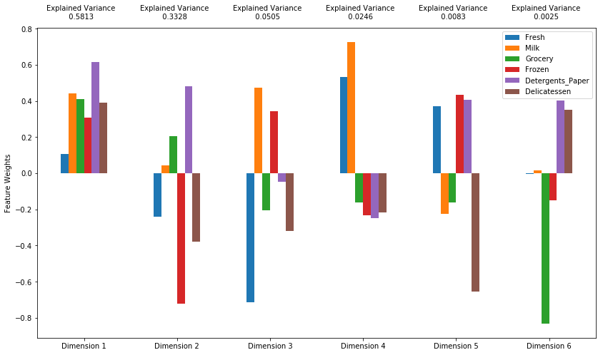

```python
# Display sample log-data after having a PCA transformation applied

pca.fit(log_samples)
pca_samples = vs.pca_results(log_samples, pca)

#display(pd.DataFrame(np.round(pca_samples, 4), columns = pca_results.index.values))
display(pca_samples)
```

### Implementation: Dimensionality Reduction

When using principal component analysis, one of the main goals is to reduce the dimensionality of the data — in effect, reducing the complexity of the problem. Dimensionality reduction comes at a cost: Fewer dimensions used implies less of the total variance in the data is being explained. Because of this, the *cumulative explained variance ratio* is extremely important for knowing how many dimensions are necessary for the problem. Additionally, if a signifiant amount of variance is explained by only two or three dimensions, the reduced data can be visualized afterwards.

In the code block below, you will need to implement the following:

- Assign the results of fitting PCA in two dimensions with `good_data` to `pca`.
- Apply a PCA transformation of `good_data` using `pca.transform`, and assign the results to `reduced_data`.
- Apply a PCA transformation of `log_samples` using `pca.transform`, and assign the results to `pca_samples`.

```python
# TODO: Apply PCA by fitting the good data with only two dimensions
pca = PCA(n_components=2)

pca.fit(good_data)


# TODO: Transform the good data using the PCA fit above
reduced_data =pca.transform(good_data)

# TODO: Transform log_samples using the PCA fit above
pca_samples = pca.transform(log_samples)

# Create a DataFrame for the reduced data
reduced_data = pd.DataFrame(reduced_data, columns = ['Dimension 1', 'Dimension 2'])
```

### Observation

Run the code below to see how the log-transformed sample data has changed after having a PCA transformation applied to it using only two dimensions. Observe how the values for the first two dimensions remains unchanged when compared to a PCA transformation in six dimensions.

```python
# Display sample log-data after applying PCA transformation in two dimensions
display(pd.DataFrame(np.round(pca_samples, 4), columns = ['Dimension 1', 'Dimension 2']))
```

|  | Dimension 1 | Dimension 2 |
| --- | --- | --- |
| 0 | -1.8004 | -0.8698 |
| 1 | 1.1273 | -1.4580 |
| 2 | 0.5605 | -2.0809 |
| 3 | -4.3780 | -3.9972 |
| 4 | 1.9647 | -0.8689 |
| 5 | -3.4242 | -1.0620 |
| 6 | 0.7379 | 3.6344 |
| 7 | 0.1273 | 0.4951 |
| 8 | -4.6018 | 0.3307 |

## Visualizing a Biplot

A biplot is a scatterplot where each data point is represented by its scores along the principal components. The axes are the principal components (in this case `Dimension 1` and `Dimension 2`). In addition, the biplot shows the projection of the original features along the components. A biplot can help us interpret the reduced dimensions of the data, and discover relationships between the principal components and original features.

Run the code cell below to produce a biplot of the reduced-dimension data.

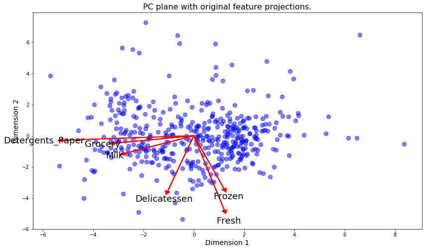

```python
# Create a biplot
vs.biplot(good_data, reduced_data, pca)
```

### Observation

From the biplot, which of the original features are most strongly correlated with the first component? What about those that are associated with the second component? Do these observations agree with the pca_results plot you obtained earlier?

## Clustering

In this section, you will choose to use either a K-Means clustering algorithm or a Gaussian Mixture Model clustering algorithm to identify the various customer segments hidden in the data. You will then recover specific data points from the clusters to understand their significance by transforming them back into their original dimension and scale.

### Question 6

- What are the advantages to using a K-Means clustering algorithm?
- What are the advantages to using a Gaussian Mixture Model clustering algorithm?
- Given your observations about the wholesale customer data so far, which of the two algorithms will you use and why?

**Hint:** Think about the differences between hard clustering and soft clustering and which would be appropriate for our dataset.

A: K Mean Clustering allows us to find groups od similar - in this case - customers buying similar product-volumes. This will allow the wholesale supplier to unsderstand his/her market better; this could lead to direct marketing the different clusters more effectively or prehaps serving the customers by grouping the items so on delivery the items more usable to the customers. K Means allows the analyst to specify the cluster number in advance as opposed to a hierarchical clustering methods. The algorithm uses squared Euclidean distance. *(p509) This algorithm makes 'deterministic' choices of in-or-out of a data point to a cluster.* (p512)

B: Gaussian Mixture Model clustering is Expection-Maximumization algorithm*. The GMM algorithm seeks to address the "mixture modeling' clustering as opposed to 'combinatorial algorithms' and 'mode seekers'.(from p507 of below*). So using this algorithm is addresses the 6 measurement variables which overlap between the latent segment clusters variables. This algorithm makes 'probabilistic' choices of in-or-out of a data point to a cluster i.e., 'soft choices'.

*from Hastie, T, et al., The Elements of Statistical Learning, 2nd Ed, Springer, 2009, p272-279 & p463, & p492, p510-512

C: I am would like to explore both EM 'GMM' and K-Means cluster approaches; but my bias is a 'probabilistic' solution, however.

### Implementation: Creating Clusters

Depending on the problem, the number of clusters that you expect to be in the data may already be known. When the number of clusters is not known *a priori*, there is no guarantee that a given number of clusters best segments the data, since it is unclear what structure exists in the data — if any. However, we can quantify the "goodness" of a clustering by calculating each data point's *silhouette coefficient*. The [silhouette coefficient](http://scikit-learn.org/stable/modules/generated/sklearn.metrics.silhouette_score.html) for a data point measures how similar it is to its assigned cluster from -1 (dissimilar) to 1 (similar). Calculating the *mean* silhouette coefficient provides for a simple scoring method of a given clustering.

In the code block below, you will need to implement the following:

- Fit a clustering algorithm to the `reduced_data` and assign it to `clusterer`.
- Predict the cluster for each data point in `reduced_data` using `clusterer.predict` and assign them to `preds`.
- Find the cluster centers using the algorithm's respective attribute and assign them to `centers`.
- Predict the cluster for each sample data point in `pca_samples` and assign them `sample_preds`.
- Import `sklearn.metrics.silhouette_score` and calculate the silhouette score of `reduced_data` against `preds`.
  - Assign the silhouette score to `score` and print the result.

```python
# TODO: Apply your clustering algorithm of choice to the reduced data
from sklearn.cluster import KMeans
from sklearn.metrics import silhouette_score

from sklearn.mixture import GMM

n_clusters1 = [2,3,4,5,6,7,8,9,10]
#n_clusters1 = [2]

######### K Means #########
for cluster11 in n_clusters1:

    clusterer = KMeans(n_clusters=cluster11).fit(reduced_data)
    #clusterer = KMeans(n_clusters=cluster11).fit(log_data)

# TODO: Predict the cluster for each data point
    #preds = clusterer.predict(log_data)
    preds = clusterer.predict(reduced_data)

# TODO: Find the cluster centers
    centers = clusterer.cluster_centers_

# TODO: Predict the cluster for each transformed sample data point
    sample_preds = clusterer.predict(pca_samples)

# TODO: Calculate the mean silhouette coefficient for the number of clusters chosen
    score = silhouette_score(reduced_data, preds )
    print "K Means For Number Clusters = {}. Silhoutte Score = {}\n".format(cluster11, score)
    #display(preds)
    display(centers)





###Gaussian Mixture Model #########################
#n_samples = 500
#C = np.array([[0., -0.1], [1.7, .4]])
#X = np.r_[np.dot(np.random.randn(n_samples, 2), C),
#          .7 * np.random.randn(n_samples, 2) + np.array([-6, 3])]
#lowest_bic = np.infty
#bic = []

n_clusters1 = [3,4,5,6,7,8,9,10]
n_clusters1 = [2,3,10,4,5,6,7,8]
#n_clusters1 = [5]

for cluster11 in n_clusters1:

    clusterer0 = GMM(n_components=cluster11,
                       random_state=5).fit(reduced_data)



#    bic.append(clusterer0.bic(X))
#    if bic[-1] < lowest_bic:
#        lowest_bic = bic[-1]
#        best_gmm = clusterer0



# TODO: Predict the cluster for each data point
    preds0 = clusterer0.predict(reduced_data)

# TODO: Find the cluster centers
    #centers1 = clusterer0.cluster_centers_  # No centers in GMM

# TODO: Predict the cluster for each transformed sample data point
    sample_preds = clusterer0.predict(pca_samples)

# TODO: Calculate the mean silhouette coefficient for the number of clusters chosen
    score0 = silhouette_score(reduced_data, preds0 )
    print "GMM For Number Clusters = {}. Silhoutte Score = {}\n".format(cluster11, score0)
    #display(preds)
    #display(centers1)  #'Note AttributeError: 'GMM' object has no attribute 'cluster_centers_'
```

```
K Means For Number Clusters = 2. Silhoutte Score = 0.419166083203
```

```
array([[-2.21426954,  0.24162188],
       [ 1.50435106, -0.16415532]])
```

```
K Means For Number Clusters = 3. Silhoutte Score = 0.392358689958
```

```
array([[ 1.77574097,  0.02617815],
       [-1.59753157, -1.2798291 ],
       [-2.0032756 ,  2.20036118]])
```

```
K Means For Number Clusters = 4. Silhoutte Score = 0.330229563532
```

```
array([[-2.21975172, -0.79448756],
       [ 0.85424165, -1.11100594],
       [-2.08219551,  2.50185199],
       [ 2.32072347,  0.87586514]])
```

```
K Means For Number Clusters = 5. Silhoutte Score = 0.346912914989
```

```
array([[ 0.43891917,  0.77865019],
       [ 2.92090039,  0.64426157],
       [-2.58596634,  2.55478066],
       [ 1.02473092, -1.60015122],
       [-2.29469907, -0.91442537]])
```

```
K Means For Number Clusters = 6. Silhoutte Score = 0.349199365855
```

```
array([[ 0.76853266, -1.88747004],
       [-2.60732238,  2.1161475 ],
       [-2.32653699, -0.92460945],
       [ 1.82498997,  4.44340064],
       [ 2.67893426,  0.04436817],
       [ 0.52768308,  0.49257911]])
```

```
K Means For Number Clusters = 7. Silhoutte Score = 0.354924383174
```

```
array([[ 3.51979403,  1.14862562],
       [-2.49123852, -0.8747803 ],
       [-0.15147681, -2.21950539],
       [-2.79819988,  1.812062  ],
       [ 1.78007677, -0.68812197],
       [-0.19596647,  5.05255655],
       [ 0.26197579,  0.62993997]])
```

```
K Means For Number Clusters = 8. Silhoutte Score = 0.357913297705
```

```
array([[-2.81454164,  1.80031183],
       [ 1.8234169 , -0.90966406],
       [-2.51402379, -0.94459206],
       [-0.2496602 ,  0.17587867],
       [ 4.42066557,  1.3215401 ],
       [-0.19596647,  5.05255655],
       [-0.04638568, -2.42740867],
       [ 1.64807567,  0.89440567]])
```

```
K Means For Number Clusters = 9. Silhoutte Score = 0.359764924394
```

```
array([[-1.34612127,  5.73981484],
       [ 1.5997781 , -1.12385676],
       [-2.86209921,  1.91357221],
       [ 4.33971685,  0.36472344],
       [-0.36847432, -2.36144582],
       [ 1.85044804,  0.53134898],
       [-2.57883799, -0.79657644],
       [ 2.56426897,  3.8464312 ],
       [-0.16723515,  0.52004523]])
```

```
K Means For Number Clusters = 10. Silhoutte Score = 0.351521063808
```

```
array([[-0.05371619,  0.65338046],
       [ 1.64866613, -1.10801168],
       [ 1.87641615,  0.50060256],
       [-0.2778136 , -2.24576479],
       [-3.76005123, -1.46546031],
       [-2.89751386,  1.9735514 ],
       [-2.06255284, -0.53108529],
       [ 4.39563511,  0.43108354],
       [-1.6587706 ,  5.71662005],
       [ 2.44128005,  3.99327028]])
```

```
GMM For Number Clusters = 2. Silhoutte Score = 0.314641043336

GMM For Number Clusters = 3. Silhoutte Score = 0.375222595239

GMM For Number Clusters = 10. Silhoutte Score = 0.322564493425
```

[output not shown]

[output cut: 158 more lines]

```
GMM For Number Clusters = 4. Silhoutte Score = 0.339343730549

GMM For Number Clusters = 5. Silhoutte Score = 0.314734201966

GMM For Number Clusters = 6. Silhoutte Score = 0.269879201284
```

[output not shown]

[output cut: 96 more lines]

```
GMM For Number Clusters = 7. Silhoutte Score = 0.311518960454

GMM For Number Clusters = 8. Silhoutte Score = 0.293497281354
```

[output not shown]

[output cut: 13 more lines]

### Question 7

- Report the silhouette score for several cluster numbers you tried.
- Of these, which number of clusters has the best silhouette score?

B: The best K-Mean silhoutte score imply 2 Cluster are best. The best GMM silhoutte score imply 3 Clusters are best.

I was asked to compare the K-means to GMM for 'run' time differences. For 440 samples, the run times were not noticably different. From the implication of the review's question. GMM is much more time consuming than K-means. My only scource for GMM is Hastie, T, et al., The Elements of Statistical Learning, p 263, p 463, p 492 & p510

I am going to stay with the K-Means of 2 Clusters.

### Cluster Visualization

Once you've chosen the optimal number of clusters for your clustering algorithm using the scoring metric above, you can now visualize the results by executing the code block below. Note that, for experimentation purposes, you are welcome to adjust the number of clusters for your clustering algorithm to see various visualizations. The final visualization provided should, however, correspond with the optimal number of clusters.

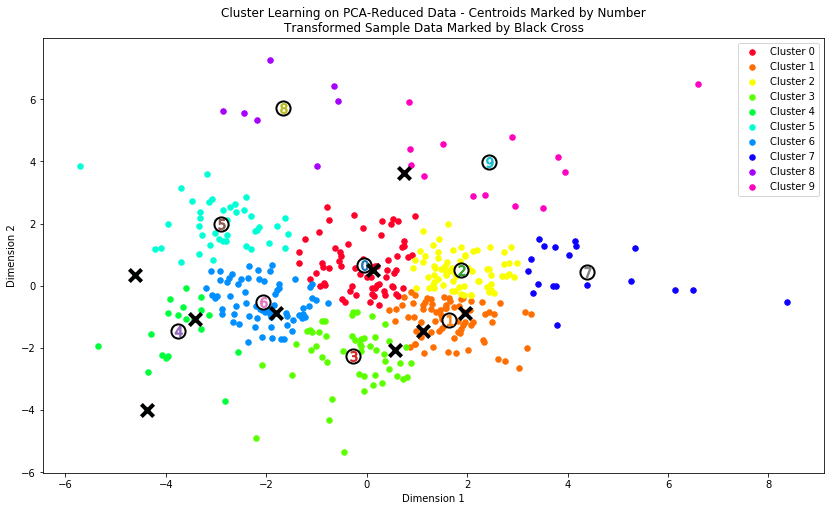

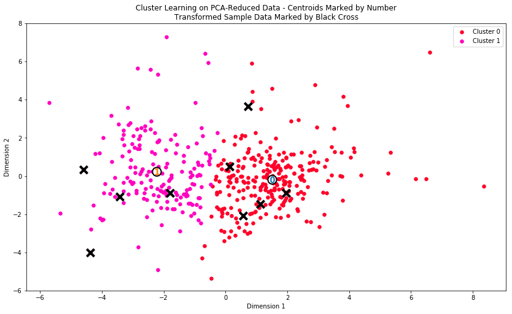

```python
# Display the results of the clustering from implementation
vs.cluster_results(reduced_data, preds, centers, pca_samples)

clusterer = KMeans(n_clusters=2).fit(reduced_data)
preds1 = clusterer.predict(reduced_data)
centers1 = clusterer.cluster_centers_

vs.cluster_results(reduced_data, preds1, centers1, pca_samples)
```

### Implementation: Data Recovery

Each cluster present in the visualization above has a central point. These centers (or means) are not specifically data points from the data, but rather the *averages* of all the data points predicted in the respective clusters. For the problem of creating customer segments, a cluster's center point corresponds to *the average customer of that segment*. Since the data is currently reduced in dimension and scaled by a logarithm, we can recover the representative customer spending from these data points by applying the inverse transformations.

In the code block below, you will need to implement the following:

- Apply the inverse transform to `centers` using `pca.inverse_transform` and assign the new centers to `log_centers`.
- Apply the inverse function of `np.log` to `log_centers` using `np.exp` and assign the true centers to `true_centers`.

```python
## Redone from earlier with 2 clusters <=> 2 centers
clusterer = KMeans(n_clusters=2).fit(reduced_data)
preds = clusterer.predict(reduced_data)
centers = clusterer.cluster_centers_
sample_preds = clusterer.predict(pca_samples)
score = silhouette_score(reduced_data, preds )


# TODO: Inverse transform the centers



log_centers = pca.inverse_transform(centers)

#xx = np.exp(8.18034392 )

# TODO: Exponentiate the centers
true_centers = np.exp(log_centers)
#print log_centers
#print true_centers
#print xx

# Display the true centers.  Note: Code is given in original
segments = ['Segment {}'.format(i) for i in range(0,len(centers))]
true_centers = pd.DataFrame(np.round(true_centers), columns = data.keys())
true_centers.index = segments
display(true_centers)
#samples
```

|  | Fresh | Milk | Grocery | Frozen | Detergents_Paper | Delicatessen |
| --- | --- | --- | --- | --- | --- | --- |
| Segment 0 | 3570.0 | 7749.0 | 12463.0 | 900.0 | 4567.0 | 966.0 |
| Segment 1 | 8994.0 | 1909.0 | 2366.0 | 2081.0 | 290.0 | 681.0 |

### Question 8

- Consider the total purchase cost of each product category for the representative data points above, and reference the statistical description of the dataset at the beginning of this project(specifically looking at the mean values for the various feature points). What set of establishments could each of the customer segments represent?

**Hint:** A customer who is assigned to `'Cluster X'` should best identify with the establishments represented by the feature set of `'Segment X'`. Think about what each segment represents in terms their values for the feature points chosen. Reference these values with the mean values to get some perspective into what kind of establishment they represent.

```
     Fresh           Milk          Grocery            Frozen    Detergents_Paper    Delicatessen
```

### Question 9

- For each sample point, which customer segment from **Question 8** best represents it?
- Are the predictions for each sample point consistent with this?*

Run the code block below to find which cluster each sample point is predicted to be.

```python
# Display the predictions
for i, pred in enumerate(sample_preds):
    print "Sample point", i, "predicted to be in Cluster", pred
```

```
Sample point 0 predicted to be in Cluster 0
Sample point 1 predicted to be in Cluster 1
Sample point 2 predicted to be in Cluster 1
Sample point 3 predicted to be in Cluster 0
Sample point 4 predicted to be in Cluster 1
Sample point 5 predicted to be in Cluster 0
Sample point 6 predicted to be in Cluster 1
Sample point 7 predicted to be in Cluster 1
Sample point 8 predicted to be in Cluster 0
```

```
Fresh   Milk    Grocery Frozen  Deter_P Delicatessen  Initial-Guess  Cluster-Selection  Observation
```

## Conclusion

In this final section, you will investigate ways that you can make use of the clustered data. First, you will consider how the different groups of customers, the *customer segments*, may be affected differently by a specific delivery scheme. Next, you will consider how giving a label to each customer (which *segment* that customer belongs to) can provide for additional features about the customer data. Finally, you will compare the *customer segments* to a hidden variable present in the data, to see whether the clustering identified certain relationships.

### Question 10

Companies will often run [A/B tests](https://en.wikipedia.org/wiki/A/B_testing) when making small changes to their products or services to determine whether making that change will affect its customers positively or negatively. The wholesale distributor is considering changing its delivery service from currently 5 days a week to 3 days a week. However, the distributor will only make this change in delivery service for customers that react positively.

- How can the wholesale distributor use the customer segments to determine which customers, if any, would react positively to the change in delivery service?*

**Hint:** Can we assume the change affects all customers equally? How can we determine which group of customers it affects the most?

Fresh foods, i.e., vegables, fruits, meal & fish - are very, very important to good restaurants wanting to stay in business in competative markets (New York City, San Francisco) whereas these restaurant may not need large Detergent-Paper deliveries daily. If these Fresh foods don't arrive daily, they can NOT be fresh and the customers will know!! (Don't go into the RESTAURANT business if you want a normal life!! I have been told.)

Make sure the Restaurants receive daily deliveries! Study increasing to twice a day deliveries costs to some restaurants.

The store can live with fewer deliveries: 3 times per week, 2 times, 1 time, maybe once a fortnight!

### Question 11

Additional structure is derived from originally unlabeled data when using clustering techniques. Since each customer has a *customer segment* it best identifies with (depending on the clustering algorithm applied), we can consider *'customer segment'* as an **engineered feature** for the data. Assume the wholesale distributor recently acquired ten new customers and each provided estimates for anticipated annual spending of each product category. Knowing these estimates, the wholesale distributor wants to classify each new customer to a *customer segment* to determine the most appropriate delivery service.

- How can the wholesale distributor label the new customers using only their estimated product spending and the **customer segment** data?

**Hint:** A supervised learner could be used to train on the original customers. What would be the target variable?

Using the clusters assignment from this problem's series of analysis, assigning a new customers becomes a classification of superviser learning. AbaBoost would be my first choice using the cusomer segments as the label of the training data fit and the new customers first week orders as the features for the Test data where are they assigned. (This outlined analysis is from the hip: I would have to do this analysis to see is this is doable!)

### Visualizing Underlying Distributions

At the beginning of this project, it was discussed that the `'Channel'` and `'Region'` features would be excluded from the dataset so that the customer product categories were emphasized in the analysis. By reintroducing the `'Channel'` feature to the dataset, an interesting structure emerges when considering the same PCA dimensionality reduction applied earlier to the original dataset.

Run the code block below to see how each data point is labeled either `'HoReCa'` (Hotel/Restaurant/Cafe) or `'Retail'` the reduced space. In addition, you will find the sample points are circled in the plot, which will identify their labeling.

```
('Total Correct Samples in Clusters=', 298, 'Total Samples = ', 440, 'Proportion Correct= 0.6773')
```

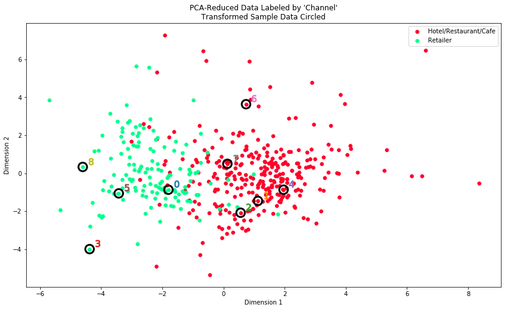

```python
# Display the clustering results based on 'Channel' data
vs.channel_results(reduced_data, outliers, pca_samples)

from sklearn.metrics import accuracy_score

channel_labels = pd.read_csv("customers.csv")["Channel"]
channel_labels = channel_labels.drop(channel_labels.index[outliers]).reset_index(drop = True) - 1
channel_labels = abs(channel_labels -1)
sum1=sum(channel_labels)
prop_accuracy=float(sum1)/len(channel_labels)

print('Total Correct Samples in Clusters=', sum1,'Total Samples = ', 440, 'Proportion Correct= {:.4f}'.format( prop_accuracy) )
```

### Question 12

- How well does the clustering algorithm and number of clusters you've chosen compare to this underlying distribution of Hotel/Restaurant/Cafe customers to Retailer customers?
- Are there customer segments that would be classified as purely 'Retailers' or 'Hotels/Restaurants/Cafes' by this distribution?
- Would you consider these classifications as consistent with your previous definition of the customer segments?

B: Using K-Means - a deterministic model - these are either segation 0 or segment 1, period. As I understand the GMM clustering, the customers are clustered as a posterior probability of being in custer 0 or cluster 1. (The Silhouette scores, the GMM said 3 clusters was higher scoring rather than two. The analyst will ignore this here.)  
The graph above, shows the 'red' Restaurant-Hotels and green 'Retailer' are NOT show clean demarcation where some green points amoung the predomiantly red points and many red amoung the predominant green points. This implies - if this were a supervised ML moswl - the accuracy, precision, recall are less than 100%.

> **Note**: Once you have completed all of the code implementations and successfully answered each question above, you may finalize your work by exporting the iPython Notebook as an HTML document. You can do this by using the menu above and navigating to  
> **File -> Download as -> HTML (.html)**. Include the finished document along with this notebook as your submission.